# TP 1 : Initiation au langage et objets de R

ModIA - 4ème année - 2023-2024

Ce script s’appuie sur le tutoriel 2 [“Initiation au langage et objets de R”](https://cmaugis.github.io/TutorielsR/Part2-InitR.html). Il vous donne un guide de lecture du tutoriel et il y est reporté des parties de code.

# Structure des objets

Sous R, les éléments de base sont des objets : des données (vecteurs, matrices, …), des fonctions, des graphiques, … Ces objets se différencient par leur mode décrivant leur contenu, et leur classe décrivant leur structure. Les objets atomiques sont de mode homogène et les objets récursifs sont de mode hétérogène. Les différents modes sont **null (objet vide), logical, numeric, complex, character**.

Les classes d’objets les plus courantes sont : **vector, matrix, array, factor, data.frame, list.** On peut avoir des vecteurs, matrices, tableaux, … de mode null (objet vide), logical (TRUE, FALSE, NA), numeric, complex, character. Par contre les listes et les tableaux peuvent être composés d’éléments hétérogènes. On utilise la commande `class()` pour connaître la classe d’un objet et `str()`pour connaitre la nature des éléments composant l’objet.

La principale difficulté en R réside dans l’identification des types d’objets manipulés. Nous allons dans ce tutoriel présenter ces différents objets, les opérations et manipulations basiques que l’on peut faire, …

On peut stocker un objet dans une variable (ex *a*) à l’aide de `a<- ...` ou `a= ...`. Pour lister les variables actuellement disponibles dans la session de travail, on utilise la fonction `ls()`. Pour effacer une ou plusieurs variables, on utilise la fonction `rm()`. La commande `rm(list=ls())` permet d’effacer toutes les variables en mémoire.

## Opération sur les scalaires

### Opérations

Les opérations élémentaires sur les scalaires sont `*`,`-`, `+`, `/`, `^`.

Executez les commandes suivantes. Vous chercherez en particulier à bien identifier les différents types de données :

```r
2+2
exp(10)
a = log(2)
a
b =cos(10)
b
a - b
a*b
d <- 2 < 3
d
dd <- FALSE
dd - d
dd + d
e<- "toto"
class(e)
str(e)
```

### `is.xxx()/as.xxx()`

Pour tester si un objet *obj* est de type *xxx*, on utilise la commande `is.xxx(obj)`. On peut aussi contraindre si possible l’objet *obj* au type *xxx* avec la commande `as.xxx(obj)`.

```r
a = 4.3
is.numeric(a)
```

```
[1] TRUE
```

```r
is.complex(a)
```

```
[1] FALSE
```

```r
is.character(a)
```

```
[1] FALSE
```

```r
as.character(a)
```

```
[1] "4.3"
```

```r
b<- "toto"
is.numeric(b)
```

```
[1] FALSE
```

```r
as.list(b)
```

```
[[1]]
[1] "toto"
```

### Arrondir

Pour obtenir des valeurs arrondies sur des valeurs numériques, vous pouvez utiliser l’une des commandes suivantes `round()`, `ceiling()`, `floor()`, `trunc()` ou `signif()` (voir l’aide `?round`). Comparez les codes suivantes:

```r
a=1.3579
floor(a)
```

```
[1] 1
```

```r
ceiling(a)
```

```
[1] 2
```

```r
round(a,digits=2)
```

```
[1] 1.36
```

```r
signif(a,digits=2)
```

```
[1] 1.4
```

```r
is.integer(floor(a))
```

```
[1] FALSE
```

```r
is.numeric(floor(a))
```

```
[1] TRUE
```

## Booléens et opérations logiques

En R, un booléen est représenté par *TRUE* ou *FALSE*. Les opérations logiques, `<`, `>`, `<=`, `>=`, `!=` (différent), `==` (égal) retournent *TRUE* ou *FALSE*. On peut définir plusieurs conditions à remplir avec les opérateurs `&` (ET) et `|` (OU).

Attention, R considère qu’un booléen a *FALSE* vaut $0$ et qu’un booléen a *TRUE* vaut $1$. Il est donc capable d’évaluer `TRUE + 5` bien qu’en toute logique, cela n’a aucun sens!

Voici quelques exemples de manipulation des booléens :

```r
a = 3
b = 6
a<=b
```

```
[1] TRUE
```

```r
a!=b
```

```
[1] TRUE
```

```r
(b-3==a) & (b>=a)
```

```
[1] TRUE
```

```r
(b==a) | (b>=a)
```

```
[1] TRUE
```

## Les caractères

On donne ici quelques fonctions de base sur la manipulation des chaînes de caractères. Dans le tutoriel 4 de R avancé, on présentera le package **stringr** qui est très utilisé pour gérer et manipuler des chaînes de caractères.

### `paste()`

Pour concaténer, juxtaposer des chaînes de caractères on utilise la fonction `paste()`

```r
Ex = paste("Bonjour", "à","toutes","et","tous","!")
paste("Bonjour", "à","toutes","et","tous","!",sep="_")
```

```
[1] "Bonjour_à_toutes_et_tous_!"
```

```r
x = c("Bonjour", "à", "vous")
paste(x)
```

```
[1] "Bonjour" "à"       "vous"
```

```r
paste(x,collapse="++")
```

```
[1] "Bonjour++à++vous"
```

### `nchar()`

On accède à la longueur d’une chaîne avec la fonction `nchar()`

```r
nchar(Ex)
```

```
[1] 26
```

### `substr()` / `substring()`

La fonction `substr()` permet d’extraire une partie d’une chaîne à partir des attributs « start » et « stop ». On peut aussi remplacer des segments d’une chaine.

```r
substr(Ex,start=3,stop=9)
```

```
[1] "njour à"
```

```r
substr(Ex, start = 3, stop = 9) <- "@@@"
Ex
```

```
[1] "Bo@@@ur à toutes et tous !"
```

On peut aussi utiliser la fonction `substring()`

```r
Ex = paste("Bonjour", "à","toutes","et","tous","!")
substring(Ex, first = 3)
```

```
[1] "njour à toutes et tous !"
```

```r
substring(Ex, first = 3, last = 9) <- "@@@--<"
Ex
```

```
[1] "Bo@@@--<à toutes et tous !"
```

### `strsplit()`

La fonction `strsplit()` permet de scinder une chaîne de caractères :

```r
Ex = paste("Bonjour", "à","toutes","et","tous","!")
strsplit(Ex,split= " ")
```

```
[[1]]
[1] "Bonjour" "à"       "toutes"  "et"      "tous"    "!"
```

```r
strsplit(Ex,split=c("o"," "))
```

```
[[1]]
[1] "B"         "nj"        "ur à t"    "utes et t" "us !"
```

La sortie de la fonction `strsplit()` est une liste (voir section sur `list`)

### `grep()`

La fonction `grep()` permet de rechercher les éléments d’une liste.

```r
Ex1 = c("tomate","concombre","mais","courgette","poivron","carotte","betterave")
Ex1
```

```
[1] "tomate"    "concombre" "mais"      "courgette" "poivron"   "carotte"
[7] "betterave"
```

```r
grep(pattern="o",Ex1,value=FALSE) # donne les indices des éléments contenant un "o" dans Ex
```

```
[1] 1 2 4 5 6
```

```r
grep(pattern="o",Ex1, value = TRUE) # Donne les éléments de Ex1 qui contiennent la lettre "o"
```

```
[1] "tomate"    "concombre" "courgette" "poivron"   "carotte"
```

On peut utiliser la fonction `grep()` avec les expressions régulières disponible sous R, il faut penser à mettre l’option `fixed=FALSE`. Pour plus de détail, voir `?regex`.

### `gsub()`

Enfin pour remplacer un pattern dans une chaine de caractère, on peut utiliser la fonction `gsub()`

```r
gsub(pattern = "o" , replacement = "@" , Ex1, fixed = TRUE)
```

```
[1] "t@mate"    "c@nc@mbre" "mais"      "c@urgette" "p@ivr@n"   "car@tte"
[7] "betterave"
```

## Vecteurs *(vector)*

Un vecteur est un ensemble ordonné d’éléments de même nature (numérique, logique ou alphanumérique). La création d’un vecteur peut se faire par la commande `c(e1,e2,...)`. On peut également générer une séquence avec la commande `seq(a,b,t)` où $a$ est le premier terme, le dernier terme est $\leq b$ et le pas est $t$. Pour créer un vecteur constitué de l’élément $x$ répété $n$ fois, on utilise la commande `rep(x,n)`.

### Exemples

On donne ici quelques exemples à tester sous R pour vous familiariser avec les vecteurs. En particulier, vous pouvez découvrir des fonctions utiles avec les vecteurs comme `length()`, `sum()`, `sort()`, … , les opérations usuelles, l’extraction d’éléments d’un vecteur, …

#### Commande `c(...)`

```r
d <- c(2,3,5,8,4,6)
d
```

```
[1] 2 3 5 8 4 6
```

```r
is.vector(d)
```

```
[1] TRUE
```

```r
c(2,5,"toto")
```

```
[1] "2"    "5"    "toto"
```

```r
1:10
```

```
 [1]  1  2  3  4  5  6  7  8  9 10
```

#### Commande `seq(...)`

```r
seq(1,10)
```

```
 [1]  1  2  3  4  5  6  7  8  9 10
```

```r
seq(from=1,to=20,by=2)
```

```
 [1]  1  3  5  7  9 11 13 15 17 19
```

```r
seq(1,20,by=5)
```

```
[1]  1  6 11 16
```

```r
seq(1,20,length=5)
```

```
[1]  1.00  5.75 10.50 15.25 20.00
```

#### Commande `rep(...)`

```r
rep(5,times=10)
```

```
 [1] 5 5 5 5 5 5 5 5 5 5
```

```r
rep(c(1,2),3)
```

```
[1] 1 2 1 2 1 2
```

```r
rep(c(1,2),each=3)
```

```
[1] 1 1 1 2 2 2
```

#### Extraire des éléments

```r
d
```

```
[1] 2 3 5 8 4 6
```

```r
d[2]
```

```
[1] 3
```

```r
d[2:3]
```

```
[1] 3 5
```

```r
d[c(1,3,6)]
```

```
[1] 2 5 6
```

```r
d[-3]
```

```
[1] 2 3 8 4 6
```

```r
d[-(1:2)]
```

```
[1] 5 8 4 6
```

#### Opérations

Additionner ou soustraire un scalaire d’un vecteur

```r
d+4
```

```
[1]  6  7  9 12  8 10
```

```r
d-4
```

```
[1] -2 -1  1  4  0  2
```

Multiplier ou diviser un vecteur par un scalaire

```r
2*d
```

```
[1]  4  6 10 16  8 12
```

```r
d/3
```

```
[1] 0.6666667 1.0000000 1.6666667 2.6666667 1.3333333 2.0000000
```

Multiplier/ diviser deux vecteurs terme à terme

```r
d
```

```
[1] 2 3 5 8 4 6
```

```r
e<- rep(2,6)
d*e
```

```
[1]  4  6 10 16  8 12
```

```r
d/e
```

```
[1] 1.0 1.5 2.5 4.0 2.0 3.0
```

#### Fonctions usuelles

```r
d = c(2,3,5,8,4,6)
d
```

```
[1] 2 3 5 8 4 6
```

Longueur d’un vecteur

```r
length(d)
```

```
[1] 6
```

Somme des termes d’un vecteur numérique

```r
sum(d)
```

```
[1] 28
```

Somme des termes cumulés d’un vecteur numérique

```r
cumsum(d)
```

```
[1]  2  5 10 18 22 28
```

Différence des termes successifs d’un vecteur numérique

```r
diff(d)
```

```
[1]  1  2  3 -4  2
```

Vérifier si *d* est un vecteur

```r
is.vector(d)
```

```
[1] TRUE
```

Transposition d’un vecteur

```r
t(d)
```

```
     [,1] [,2] [,3] [,4] [,5] [,6]
[1,]    2    3    5    8    4    6
```

Produit scalaire

```r
t(d)%*%e
```

```
     [,1]
[1,]   56
```

NA (Not Available) signale une donnée manquante

```r
d[3] <- NA
d
```

```
[1]  2  3 NA  8  4  6
```

```r
is.na(d)
```

```
[1] FALSE FALSE  TRUE FALSE FALSE FALSE
```

```r
any(is.na(d))
```

```
[1] TRUE
```

```r
all(is.na(d))
```

```
[1] FALSE
```

Autres fonctions interrsantes avec les vecteurs : `abs()`, `sort()`, `order()`, `which()`, …

```r
a<-c(3,-1,5,2,-7,3,9)
b<-c(TRUE,FALSE,FALSE,TRUE,FALSE)
abs(a)
```

```
[1] 3 1 5 2 7 3 9
```

```r
sort(a)
```

```
[1] -7 -1  2  3  3  5  9
```

```r
order(a)
```

```
[1] 5 2 4 1 6 3 7
```

```r
b = a==3
b
```

```
[1]  TRUE FALSE FALSE FALSE FALSE  TRUE FALSE
```

```r
sort(b)
```

```
[1] FALSE FALSE FALSE FALSE FALSE  TRUE  TRUE
```

```r
text<-c("petit","moyen","grand")
is.vector(text)
```

```
[1] TRUE
```

```r
f = c(a=12,b=26,c=32,d=41)
f
```

```
 a  b  c  d
12 26 32 41
```

```r
names(f)
```

```
[1] "a" "b" "c" "d"
```

```r
f["a"]
```

```
 a
12
```

```r
names(f)<-c("a1","a2","a3","a4")
f
```

```
a1 a2 a3 a4
12 26 32 41
```

Notez la différence entre les commandes suivantes :

```r
f>30
```

```
   a1    a2    a3    a4
FALSE FALSE  TRUE  TRUE
```

```r
f[f>30]
```

```
a3 a4
32 41
```

```r
which(f>30)
```

```
a3 a4
 3  4
```

```r
f[2] <- 22
f+100
```

```
 a1  a2  a3  a4
112 122 132 141
```

Etonnant ces commandes suivantes, non ?

```r
f
```

```
a1 a2 a3 a4
12 22 32 41
```

```r
d
```

```
[1]  2  3 NA  8  4  6
```

```r
f+d
```

```
[1] 14 25 NA 49 16 28
```

On peut appliquer une fonction à tous les éléments d’un vecteur facilement.

```r
cos(f)
```

```
        a1         a2         a3         a4
 0.8438540 -0.9999608  0.8342234 -0.9873393
```

### Exercice

#### Enoncé

Question 1 : Créer les vecteurs suivants :

- le vecteur $a$ constitué des entiers pairs jusqu’à 30
- le vecteur $b$ contenant $v=5$, deux fois la valeur de $v$, puis un tiers de la valeur de $v$, puis trois fois $v^2$, puis $\sqrt{v}$, puis le quatrième élément de $a$.
- le vecteur $c$ contenant 6 chiffres compris entre 4 et 30 avec un intervalle constant.
- le vecteur $d$ contenant la somme des éléments de $c$, puis la longueur de $b$, puis 5 fois le chiffre 3.

Question 2 : Extraire du vecteur $a$ :

- le quatrième élément
- tous les éléments sauf le quatrième
- tous les éléments supérieurs à 10

Question 3 : À quoi sert la fonction `unique` ? Illustrer son fonctionnement sur un exemple.

#### Votre réponse

```r
a = seq(0, 30, by=2)
a
```

```
 [1]  0  2  4  6  8 10 12 14 16 18 20 22 24 26 28 30
```

```r
v = 5
b = c(v, 2*v, v/3, v**2, sqrt(v), a[4])
b
```

```
[1]  5.000000 10.000000  1.666667 25.000000  2.236068  6.000000
```

```r
c = seq(4,30,length=6)
c
```

```
[1]  4.0  9.2 14.4 19.6 24.8 30.0
```

```r
d=c(sum(c),length(b),rep(3,5))
d
```

```
[1] 102   6   3   3   3   3   3
```

```r
a[4]
```

```
[1] 6
```

```r
a[-4]
```

```
 [1]  0  2  4  8 10 12 14 16 18 20 22 24 26 28 30
```

```r
a[which(a>10)]
```

```
 [1] 12 14 16 18 20 22 24 26 28 30
```

## Matrices (*matrix*)

Comme les vecteurs, les matrices sont de mode quelconque mais ne contiennent que des éléments de même nature. Pour créer une matrice, on utilise la commande `matrix(vec,nrow=n,ncol=p)` où *vec* est le vecteur contenant les éléments de la matrice de taille $n$ par $p$, qui seront rangés en colonne sauf si l’option *byrow=T* est utilisée.

### Exemples

On donne ici quelques exemples à tester sous R pour vous familiariser avec les matrices. En particulier, vous pouvez découvrir des fonctions utiles avec les matrices comme `dim()`, `t()`, `cbind()`, `rbind()`… , les opérations usuelles dont la différence entre `A*B` et `A%*%B`, l’extraction d’éléments d’une matrice, …

#### `matrix()`

```r
A = matrix(1:15,ncol=5)
A
```

```
     [,1] [,2] [,3] [,4] [,5]
[1,]    1    4    7   10   13
[2,]    2    5    8   11   14
[3,]    3    6    9   12   15
```

```r
class(A)
```

```
[1] "matrix" "array"
```

```r
B = matrix(1:15,nc=5,byrow=T)
B2 = B
B2[1,1]="toto"
B2
```

```
     [,1]   [,2] [,3] [,4] [,5]
[1,] "toto" "2"  "3"  "4"  "5"
[2,] "6"    "7"  "8"  "9"  "10"
[3,] "11"   "12" "13" "14" "15"
```

```r
rownames(A)=c(paste("ligne",1:3,sep=""))
A
```

```
       [,1] [,2] [,3] [,4] [,5]
ligne1    1    4    7   10   13
ligne2    2    5    8   11   14
ligne3    3    6    9   12   15
```

#### Extraire

```r
A
```

```
       [,1] [,2] [,3] [,4] [,5]
ligne1    1    4    7   10   13
ligne2    2    5    8   11   14
ligne3    3    6    9   12   15
```

```r
A[1,3]
```

[output not shown]

```r
A[,2]
```

```
ligne1 ligne2 ligne3
     4      5      6
```

```r
A[2,]
```

```
[1]  2  5  8 11 14
```

```r
A[1:3,c(2,5)]
```

```
       [,1] [,2]
ligne1    4   13
ligne2    5   14
ligne3    6   15
```

```r
A[1:3,-c(2,5)]
```

```
       [,1] [,2] [,3]
ligne1    1    7   10
ligne2    2    8   11
ligne3    3    9   12
```

#### `cbind() / rbind()`

Pour concaténer deux matrices, on peut utiliser les fonctions `rbind()` ou `cbind()`.

```r
A
```

```
       [,1] [,2] [,3] [,4] [,5]
ligne1    1    4    7   10   13
ligne2    2    5    8   11   14
ligne3    3    6    9   12   15
```

```r
B
```

```
     [,1] [,2] [,3] [,4] [,5]
[1,]    1    2    3    4    5
[2,]    6    7    8    9   10
[3,]   11   12   13   14   15
```

```r
cbind(A,B)
```

```
       [,1] [,2] [,3] [,4] [,5] [,6] [,7] [,8] [,9] [,10]
ligne1    1    4    7   10   13    1    2    3    4     5
ligne2    2    5    8   11   14    6    7    8    9    10
ligne3    3    6    9   12   15   11   12   13   14    15
```

```r
rbind(A,B)
```

```
       [,1] [,2] [,3] [,4] [,5]
ligne1    1    4    7   10   13
ligne2    2    5    8   11   14
ligne3    3    6    9   12   15
          1    2    3    4    5
          6    7    8    9   10
         11   12   13   14   15
```

#### Fonctions utiles

Dimension d’une matrice

```r
dim(A)
```

```
[1] 3 5
```

Nombre de lignes et de colonnes

```r
nrow(A)
```

```
[1] 3
```

```r
ncol(A)
```

```
[1] 5
```

Transposée et déterminant d’une matrice

```r
t(A)
```

```
     ligne1 ligne2 ligne3
[1,]      1      2      3
[2,]      4      5      6
[3,]      7      8      9
[4,]     10     11     12
[5,]     13     14     15
```

```r
det(A[,3:5])
```

```
[1] 0
```

Inversion d’une matrice

```r
solve(A[1:2,2:3])
```

```
        ligne1    ligne2
[1,] -2.666667  2.333333
[2,]  1.666667 -1.333333
```

Matrice diagonale et diagonale d’une matrice

```r
diag(A)
```

```
[1] 1 5 9
```

```r
diag(1:5)
```

```
     [,1] [,2] [,3] [,4] [,5]
[1,]    1    0    0    0    0
[2,]    0    2    0    0    0
[3,]    0    0    3    0    0
[4,]    0    0    0    4    0
[5,]    0    0    0    0    5
```

Matrice de booléens

```r
A>5
```

```
        [,1]  [,2] [,3] [,4] [,5]
ligne1 FALSE FALSE TRUE TRUE TRUE
ligne2 FALSE FALSE TRUE TRUE TRUE
ligne3 FALSE  TRUE TRUE TRUE TRUE
```

```r
A[A<5]<-0
A
```

```
       [,1] [,2] [,3] [,4] [,5]
ligne1    0    0    7   10   13
ligne2    0    5    8   11   14
ligne3    0    6    9   12   15
```

Quelques autres fonctions sur les matrices

```r
colSums(A)
```

```
[1]  0 11 24 33 42
```

```r
apply(A,2,sum)
```

```
[1]  0 11 24 33 42
```

```r
rowSums(A)
```

```
ligne1 ligne2 ligne3
    30     38     42
```

```r
apply(A,1,sum)
```

```
ligne1 ligne2 ligne3
    30     38     42
```

```r
rowMeans(A)
```

```
ligne1 ligne2 ligne3
   6.0    7.6    8.4
```

```r
apply(A,1,mean)
```

```
ligne1 ligne2 ligne3
   6.0    7.6    8.4
```

```r
apply(A,1,max)
```

```
ligne1 ligne2 ligne3
    13     14     15
```

Remarque : on reverra dans la section Programmation la fonction `apply()` qui permet en particulier d’éviter les boucles *for*.

#### Opérations

Attention à la multiplication matricielle `%*%` et la multiplication terme à terme `*`!

Operations terme à terme de 2 matrices

```r
A+B
```

```
       [,1] [,2] [,3] [,4] [,5]
ligne1    1    2   10   14   18
ligne2    6   12   16   20   24
ligne3   11   18   22   26   30
```

```r
A*B
```

```
       [,1] [,2] [,3] [,4] [,5]
ligne1    0    0   21   40   65
ligne2    0   35   64   99  140
ligne3    0   72  117  168  225
```

Multiplication de matrices

```r
t(B) %*%A
```

```
     [,1] [,2] [,3] [,4] [,5]
[1,]    0   96  154  208  262
[2,]    0  107  178  241  304
[3,]    0  118  202  274  346
[4,]    0  129  226  307  388
[5,]    0  140  250  340  430
```

Multiplication par un scalaire

```r
5*A
```

```
       [,1] [,2] [,3] [,4] [,5]
ligne1    0    0   35   50   65
ligne2    0   25   40   55   70
ligne3    0   30   45   60   75
```

### Exercice

#### Enoncé

1. Créer la matrice $A=\left(\begin{array}{c c c } 3 & 3 & 3\\ 4 & 4 & 4\\ 5 & 5 & 5\end{array}\right).$
2. Ajouter 2 à tous les éléments de $A$.
3. Créer la matrice $B$ en ajoutant la ligne $(1,2,3)$ à $A$, puis la colonne $(1,1,1,1)'$. Déterminer la dimension de $B$.
4. Extraire de $B$ la sous-matrice $C$ composée des deux premières colonnes et des deux dernières lignes. Calculer sa transposée et son déterminant. Inverser cette sous-matrice $C$.

#### Votre réponse

```r
A = matrix(c(rep(3, 3), rep(4, 3), rep(5, 3)), ncol = 3, byrow = T)
A
```

```
     [,1] [,2] [,3]
[1,]    3    3    3
[2,]    4    4    4
[3,]    5    5    5
```

```r
A+2
```

```
     [,1] [,2] [,3]
[1,]    5    5    5
[2,]    6    6    6
[3,]    7    7    7
```

```r
A=rbind(A,c(1,2,3))
A
```

```
     [,1] [,2] [,3]
[1,]    3    3    3
[2,]    4    4    4
[3,]    5    5    5
[4,]    1    2    3
```

```r
B=cbind(A,c(1,1,1,1))
A
```

```
     [,1] [,2] [,3]
[1,]    3    3    3
[2,]    4    4    4
[3,]    5    5    5
[4,]    1    2    3
```

```r
dim(B)
```

```
[1] 4 4
```

```r
C = B[(3:4), (1:2)]
C
```

```
     [,1] [,2]
[1,]    5    5
[2,]    1    2
```

```r
t(C)
```

```
     [,1] [,2]
[1,]    5    1
[2,]    5    2
```

```r
det(C)
```

```
[1] 5
```

```r
solve(C)
```

```
     [,1] [,2]
[1,]  0.4   -1
[2,] -0.2    1
```

## Les tableaux (array)

Les tableaux sont des matrices de dimensions supérieures à 2. On peut les générer à partir de la commande `array(vec,c(n,p,q,...))` où *vec* est le vecteur contenant les éléments du tableau et l’argument *c(n,p,q,…)* désigne les dimensions du tableau: $n$ lignes, $p$ colonnes, $q$ matrices, …

### `array()`

```r
E=array(c(1:8,rep(1,8),seq(0,1,len=8)),dim = c(2,4,3))
E
```

```
, , 1

     [,1] [,2] [,3] [,4]
[1,]    1    3    5    7
[2,]    2    4    6    8

, , 2

     [,1] [,2] [,3] [,4]
[1,]    1    1    1    1
[2,]    1    1    1    1

, , 3

          [,1]      [,2]      [,3]      [,4]
[1,] 0.0000000 0.2857143 0.5714286 0.8571429
[2,] 0.1428571 0.4285714 0.7142857 1.0000000
```

```r
E[, , 1]
```

```
     [,1] [,2] [,3] [,4]
[1,]    1    3    5    7
[2,]    2    4    6    8
```

### Fonctions usuelles

```r
dim(E)
```

```
[1] 2 4 3
```

```r
length(E)
```

```
[1] 24
```

```r
nrow(E)
```

```
[1] 2
```

```r
ncol(E)
```

```
[1] 4
```

```r
aperm(E)
```

```
, , 1

     [,1]      [,2]      [,3]      [,4]
[1,]    1 3.0000000 5.0000000 7.0000000
[2,]    1 1.0000000 1.0000000 1.0000000
[3,]    0 0.2857143 0.5714286 0.8571429

, , 2

          [,1]      [,2]      [,3] [,4]
[1,] 2.0000000 4.0000000 6.0000000    8
[2,] 1.0000000 1.0000000 1.0000000    1
[3,] 0.1428571 0.4285714 0.7142857    1
```

```r
E+10
```

```
, , 1

     [,1] [,2] [,3] [,4]
[1,]   11   13   15   17
[2,]   12   14   16   18

, , 2

     [,1] [,2] [,3] [,4]
[1,]   11   11   11   11
[2,]   11   11   11   11

, , 3

         [,1]     [,2]     [,3]     [,4]
[1,] 10.00000 10.28571 10.57143 10.85714
[2,] 10.14286 10.42857 10.71429 11.00000
```

### `apply()`

```r
H = array(1:12,c(2,3,2))
H
```

```
, , 1

     [,1] [,2] [,3]
[1,]    1    3    5
[2,]    2    4    6

, , 2

     [,1] [,2] [,3]
[1,]    7    9   11
[2,]    8   10   12
```

```r
apply(H,1,sum)
```

```
[1] 36 42
```

```r
sum(c(1,3,5,7,9,11))
```

```
[1] 36
```

```r
apply(H,2,sum)
```

```
[1] 18 26 34
```

```r
sum(c(1,2,7,8))
```

```
[1] 18
```

```r
apply(H,3,sum)
```

```
[1] 21 57
```

```r
sum(1:6)
```

```
[1] 21
```

## Listes *(list)*

Une liste est une collection ordonnée d’objets qui peuvent être de nature différente. Les listes sont en particulier utilisées par certaines fonctions (cf section Programmation) pour renvoyer des résultats complexes sous forme d’un seul objet. On utilise la fonction `list(nom1=el1,nom2=el2,...)` (l’utilisation des noms étant facultative) pour générer une liste. On peut accéder à chaque élément de la liste à l’aide de son index entre double crochets `[[...]]`, ou par son nom précédé du signe `$`.

### Exemples

#### `list(...)`

```r
x = list("toto",1:8)
x
```

```
[[1]]
[1] "toto"

[[2]]
[1] 1 2 3 4 5 6 7 8
```

```r
class(x)
```

```
[1] "list"
```

Création d’une liste avec des noms aux éléments

```r
y = list(matrice=matrix(1:15,ncol=5),
         vecteur=seq(1,20,by=5),
         texte="toto",scalaire=8)
y
```

```
$matrice
     [,1] [,2] [,3] [,4] [,5]
[1,]    1    4    7   10   13
[2,]    2    5    8   11   14
[3,]    3    6    9   12   15

$vecteur
[1]  1  6 11 16

$texte
[1] "toto"

$scalaire
[1] 8
```

#### Extraction

Extraction d’un élément par son numéro

```r
x[[1]]
```

```
[1] "toto"
```

Attention, cette commande n’est pas possible:

```r
x[[1]]+1
```

par contre celle-ci est possible

```r
x[[2]]+10
```

```
[1] 11 12 13 14 15 16 17 18
```

```r
y[[1]]
```

```
     [,1] [,2] [,3] [,4] [,5]
[1,]    1    4    7   10   13
[2,]    2    5    8   11   14
[3,]    3    6    9   12   15
```

```r
y$matrice
```

```
     [,1] [,2] [,3] [,4] [,5]
[1,]    1    4    7   10   13
[2,]    2    5    8   11   14
[3,]    3    6    9   12   15
```

```r
y$vec
```

```
[1]  1  6 11 16
```

```r
y[c("texte","scalaire")]
```

```
$texte
[1] "toto"

$scalaire
[1] 8
```

#### Fonctions utiles

```r
names(y)
```

```
[1] "matrice"  "vecteur"  "texte"    "scalaire"
```

```r
length(y)
```

```
[1] 4
```

```r
length(y$vecteur)
```

```
[1] 4
```

```r
cos(y$scal)+y[[2]][1]
```

```
[1] 0.8545
```

```r
summary(y)
```

```
         Length Class  Mode
matrice  15     -none- numeric
vecteur   4     -none- numeric
texte     1     -none- character
scalaire  1     -none- numeric
```

### Exercice

#### Enoncé

1. Créer une liste contenant le nom de trois matières, les notes de 5 élèves pour chacune de ces matières, l’âge des 5 élèves et la filière (PO) d’appartenance de ces 5 élèves.
2. Récupérer les notes du 4ème élève
3. Créer une matrice contenant les notes et l’âge des 5 élèves.

#### Votre réponse

```r
l=list(matieres=c("Maths","Info","Physique"),notes=rep(15,5),age=rep(20,5),filiere=rep("ModIA",5))
l
```

```
$matieres
[1] "Maths"    "Info"     "Physique"

$notes
[1] 15 15 15 15 15

$age
[1] 20 20 20 20 20

$filiere
[1] "ModIA" "ModIA" "ModIA" "ModIA" "ModIA"
```

```r
l$notes[4]
```

```
[1] 15
```

```r
cbind(l$notes,l$age)
```

```
     [,1] [,2]
[1,]   15   20
[2,]   15   20
[3,]   15   20
[4,]   15   20
[5,]   15   20
```

```r
# AIDEZ VOUS DE LA CORRECTION DISPO SUR LE TUTORIEL SI VOUS ETES BLOQUE
```

## Data frames

Sous R, un data.frame est analogue à une matrice mais le contenu des colonnes peut être ici hétérogène. Un tableau de données est un ensemble de vecteurs rangés colonne par colonne, chaque colonne correspondant à une variable, chaque ligne à un individu. En particulier, lors d’études statistiques, les données à étudier sont souvent représentées par un data.frame sous R. Pour créer un tableau de données, on peut regrouper des variables de même longueur à l’aide de la commande `data.frame(nom1=var1,nom2=var2,...)`. On peut par exemple transformer une matrice en un tableau de données en utilisant la commande `as.data.frame(mat)`.

### Exemple

On donne ici quelques exemples à tester sous R pour vous familiariser avec les data.frames. En particulier, vous pouvez découvrir des fonctions utiles dont `summary()`, `attach()`, …

#### `data.frame()`

```r
# Création du data.frame H
taille = runif(12,150,180)
masse = runif(12,50,90)
sexe = rep(c("M","F","F","M"),3)
H = data.frame(taille,masse,sexe)
H
```

```
     taille    masse sexe
1  151.0374 85.69299    M
2  165.1997 59.38611    F
3  177.4459 74.39741    F
4  172.6696 60.79336    M
5  163.0343 73.07759    M
6  155.6011 57.02178    F
7  170.5621 77.55879    F
8  154.5322 86.91341    M
9  179.3761 52.25778    M
10 151.4380 72.39809    F
11 166.5708 73.70265    F
12 158.8463 57.18170    M
```

```r
class(H)
```

```
[1] "data.frame"
```

#### `summary()/head()`

La fonction `summary()` permet de résumer le contenu des différentes colonnes d’un data.frame.

```r
summary(H)
```

```
     taille          masse           sexe
 Min.   :151.0   Min.   :52.26   Length:12
 1st Qu.:155.3   1st Qu.:58.84   Class :character
 Median :164.1   Median :72.74   Mode  :character
 Mean   :163.9   Mean   :69.20
 3rd Qu.:171.1   3rd Qu.:75.19
 Max.   :179.4   Max.   :86.91
```

La fonction `head()` permet de visualiser les premières lignes d’un data.frame

```r
head(H)
```

```
    taille    masse sexe
1 151.0374 85.69299    M
2 165.1997 59.38611    F
3 177.4459 74.39741    F
4 172.6696 60.79336    M
5 163.0343 73.07759    M
6 155.6011 57.02178    F
```

#### data.frame / list/matrix

Au travers de ces quelques commandes, vous pouvez voir les analogies entre data.frame, list et matrix mais restez prudent sur la nature de l’objet que vous manipulez!

```r
H[1,]
```

```
    taille    masse sexe
1 151.0374 85.69299    M
```

```r
H$taille
```

```
 [1] 151.0374 165.1997 177.4459 172.6696 163.0343 155.6011 170.5621 154.5322
 [9] 179.3761 151.4380 166.5708 158.8463
```

```r
H$sexe
```

```
 [1] "M" "F" "F" "M" "M" "F" "F" "M" "M" "F" "F" "M"
```

```r
is.data.frame(H)
```

```
[1] TRUE
```

```r
is.matrix(H)
```

```
[1] FALSE
```

```r
MH = as.matrix(H)
MH
```

```
      taille     masse      sexe
 [1,] "151.0374" "85.69299" "M"
 [2,] "165.1997" "59.38611" "F"
 [3,] "177.4459" "74.39741" "F"
 [4,] "172.6696" "60.79336" "M"
 [5,] "163.0343" "73.07759" "M"
 [6,] "155.6011" "57.02178" "F"
 [7,] "170.5621" "77.55879" "F"
 [8,] "154.5322" "86.91341" "M"
 [9,] "179.3761" "52.25778" "M"
[10,] "151.4380" "72.39809" "F"
[11,] "166.5708" "73.70265" "F"
[12,] "158.8463" "57.18170" "M"
```

```r
summary(MH)
```

```
    taille             masse               sexe
 Length:12          Length:12          Length:12
 Class :character   Class :character   Class :character
 Mode  :character   Mode  :character   Mode  :character
```

```r
as.list(H)
```

```
$taille
 [1] 151.0374 165.1997 177.4459 172.6696 163.0343 155.6011 170.5621 154.5322
 [9] 179.3761 151.4380 166.5708 158.8463

$masse
 [1] 85.69299 59.38611 74.39741 60.79336 73.07759 57.02178 77.55879 86.91341
 [9] 52.25778 72.39809 73.70265 57.18170

$sexe
 [1] "M" "F" "F" "M" "M" "F" "F" "M" "M" "F" "F" "M"
```

#### `attach()/detach()`

La fonction `attach()` permet d’accéder aux variables d’un data.frame sans appeler le data.frame.

La fonction `detach()` peut être utilisée pour supprimer la variable d’un data.frame, qui était précédemment attachée avec `attach()`.

```r
rm(taille)
H$taille
```

```
 [1] 151.0374 165.1997 177.4459 172.6696 163.0343 155.6011 170.5621 154.5322
 [9] 179.3761 151.4380 166.5708 158.8463
```

```r
attach(H)
taille
```

```
 [1] 151.0374 165.1997 177.4459 172.6696 163.0343 155.6011 170.5621 154.5322
 [9] 179.3761 151.4380 166.5708 158.8463
```

```r
detach(H) # taille est alors introuvable
```

### Exercice

#### Enoncé

On reprend le data.frame $H$ contruit dans la sous-section Exemple.

1. Extraire la masse des individus dont la taille est supérieure à 160.
2. Extraire la masse et le sexe de ces mêmes individus.
3. Extraire la taille des individus de sexe masculin dont la masse est inférieure à 80 (c’est possible en une seule ligne avec `&`).

#### Votre réponse

```r
H$masse[H$taille > 160]
```

```
[1] 59.38611 74.39741 60.79336 73.07759 77.55879 52.25778 73.70265
```

```r
H[H$taille > 160, c("masse", "sexe")]
```

```
      masse sexe
2  59.38611    F
3  74.39741    F
4  60.79336    M
5  73.07759    M
7  77.55879    F
9  52.25778    M
11 73.70265    F
```

```r
H[H$sexe=="M" & H$masse<80,"taille"]
```

```
[1] 172.6696 163.0343 179.3761 158.8463
```

```r
# AIDEZ VOUS DE LA CORRECTION DISPO SUR LE TUTORIEL SI VOUS ETES BLOQUE
```

# Premiers graphiques

Lire les explications données dans le tutoriel.

## Exemples

### Exemple 1

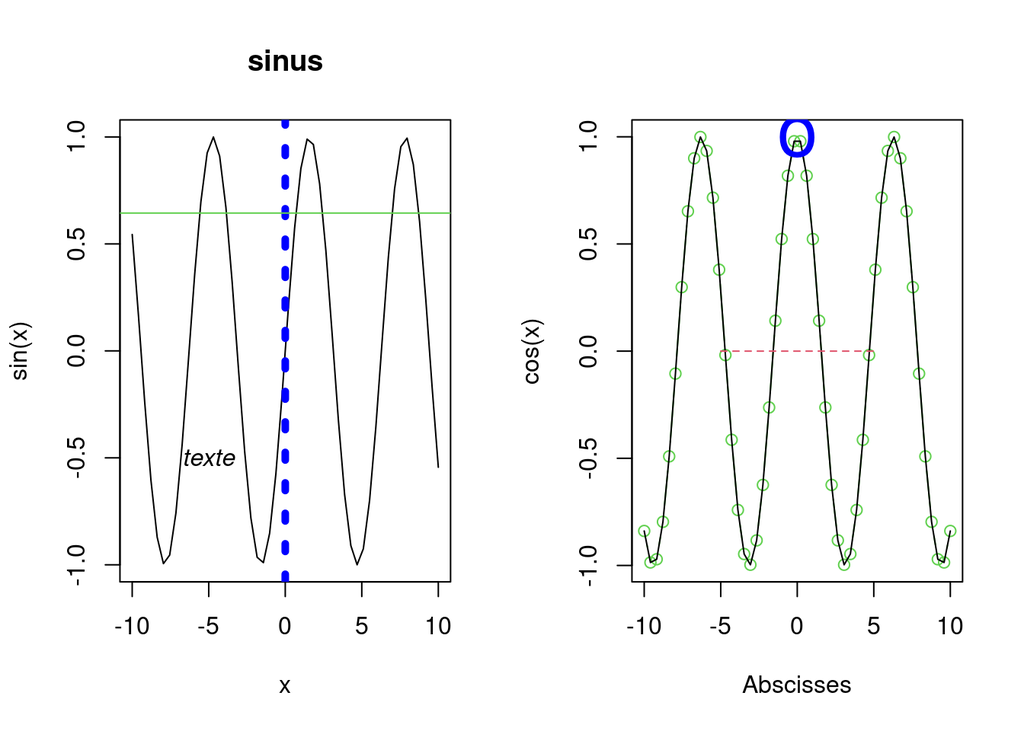

```r
x=seq(-10,10,l=50)
# 2 graphiques
par(mfrow=c(1,2))
# premier graphique
plot(x,sin(x),type="l",col=1,main="sinus")
abline(v=0,col="blue",lwd=5,lty=3)
abline(h=sin(0.7),col=3)
text(-5,-0.5,"texte",font=3)
# deuxieme graphique
plot(x,cos(x),type="b",col=3,xlab="Abscisses")
points(x,cos(x),type="l")
points(0,1,pch="o",cex=3,col="blue")
lines(c(-5,5),c(0,0),lty=2,col=2)
```

### Exemple 2

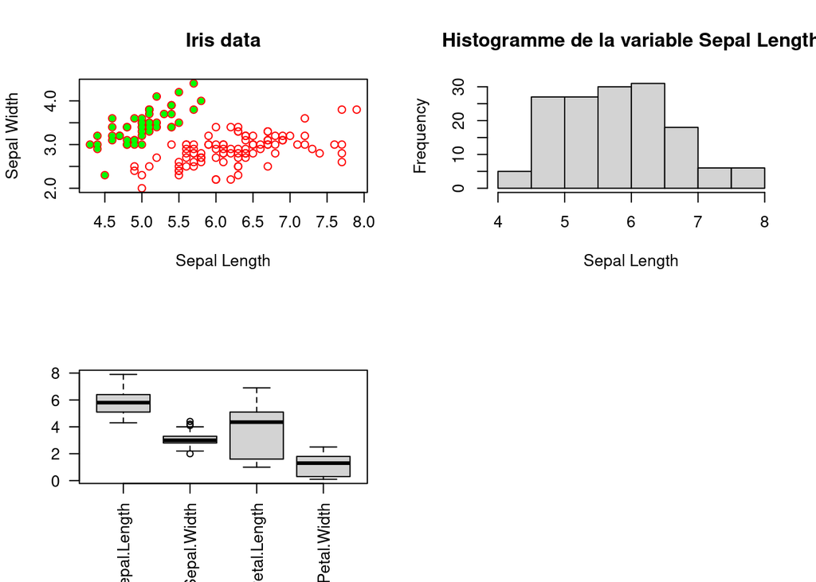

```r
data(iris)
par(mfrow=c(2,2))
plot(iris[,1],iris[,2],xlab="Sepal Length",
ylab="Sepal Width",main="Iris data",
col="red",type="p")
points(iris[iris$Species=="setosa",1],iris[iris$Species=="setosa",2],col="green",pch=20)
hist(iris[,1],xlab="Sepal Length",
main="Histogramme de la variable Sepal Length")
boxplot(iris[,1:4],las=2)
```

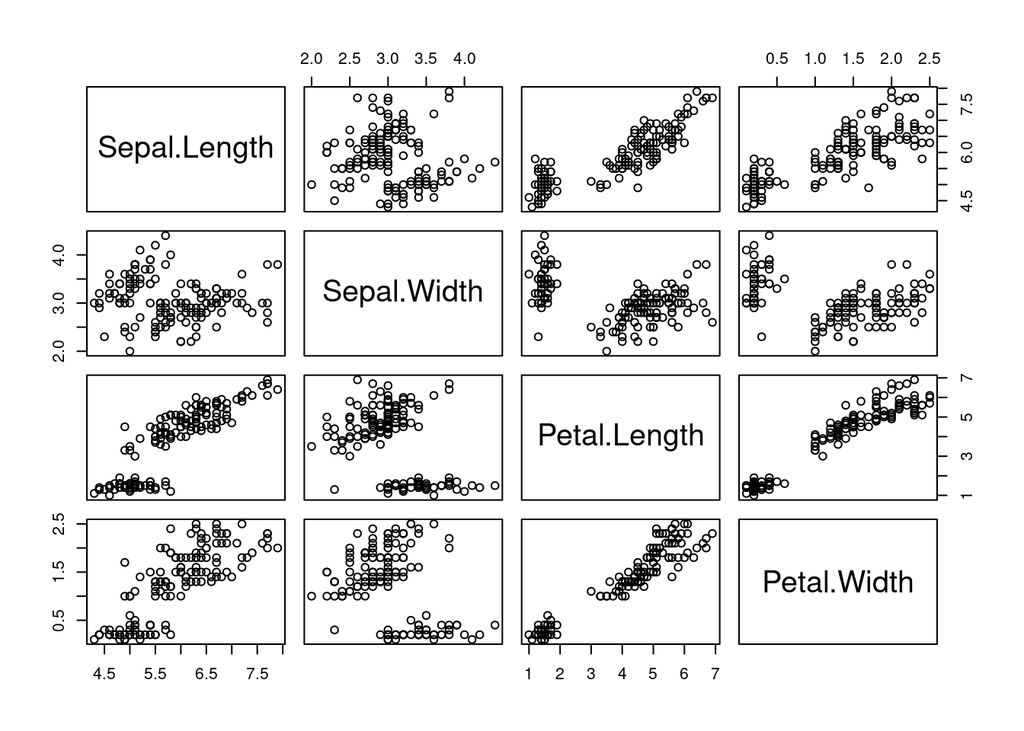

```r
pairs(iris[,1:4])
```

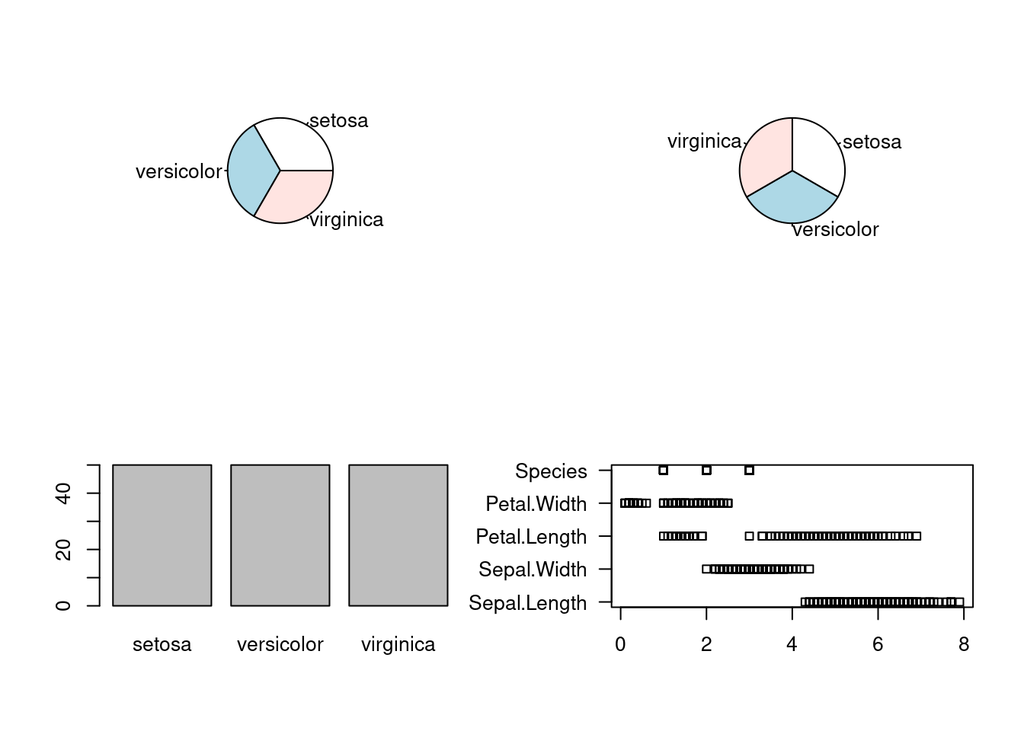

```r
par(mfrow=c(2,2))
pie(table(iris[,5]))
pie(table(iris[,5]),clockwise=T)
barplot(table(iris[,5]))
stripchart(iris,las=1)
```

### Exemple 3

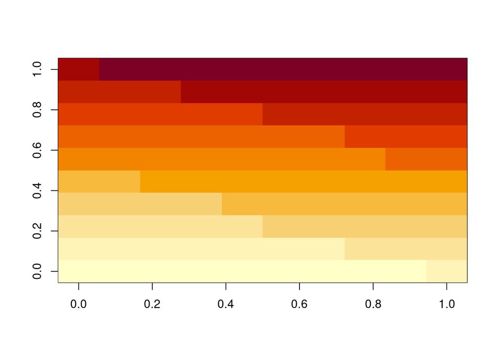

```r
M=matrix(1:100,ncol=10)
image(M)
```

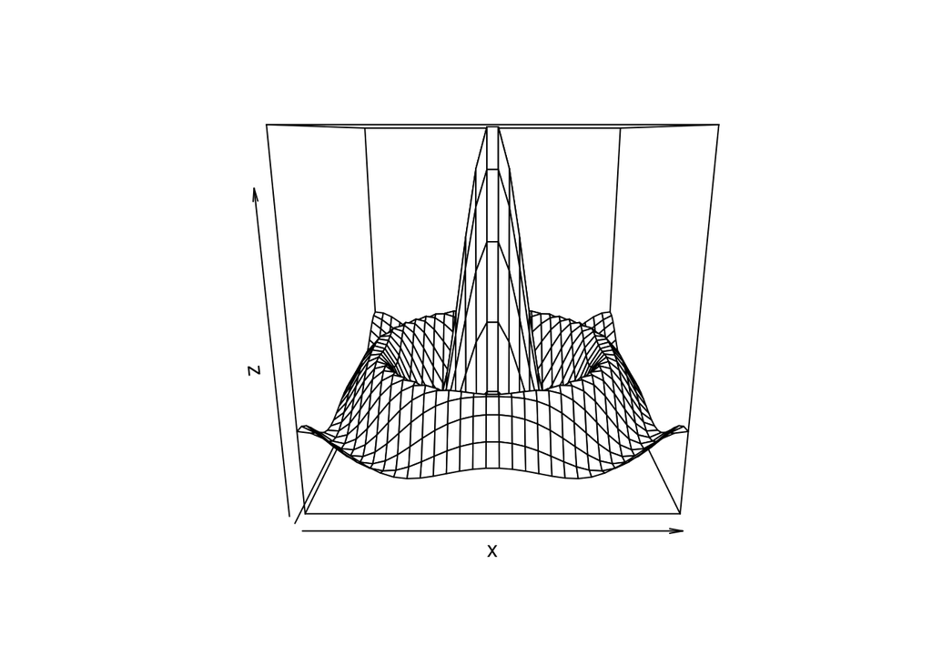

```r
x = seq(-10, 10, length= 30);y=x
f = function(x,y){r=sqrt(x^2+y^2); 10 * sin(r)/r}
z = outer(x, y, f)
z[is.na(z)] = 1
persp(x,y,z)
```

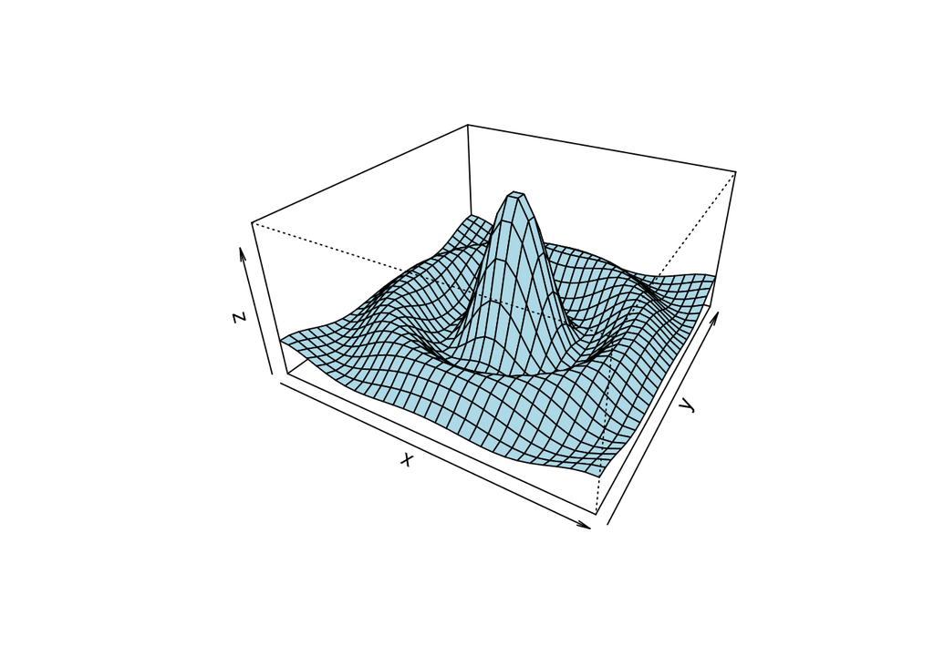

```r
persp(x, y, z, theta=30, phi=30,expand = 0.5,
   col="lightblue")
```

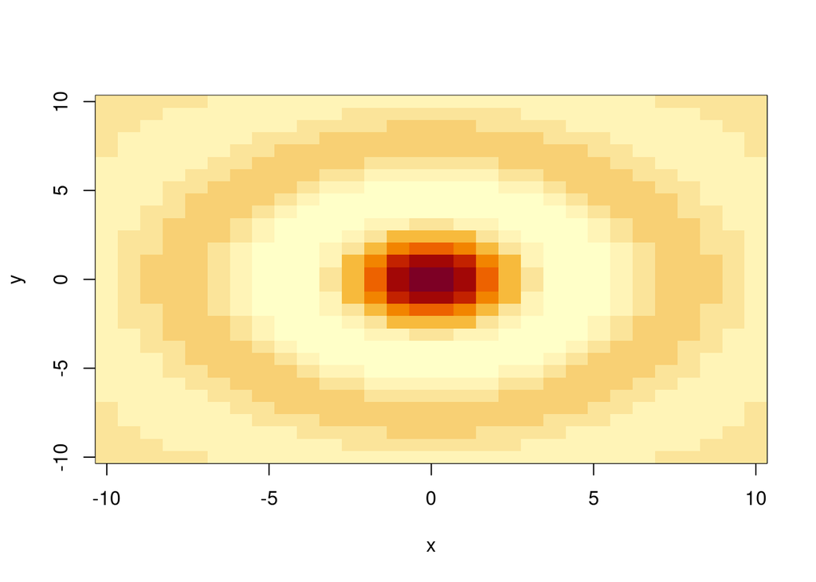

```r
image(x,y,z)
```

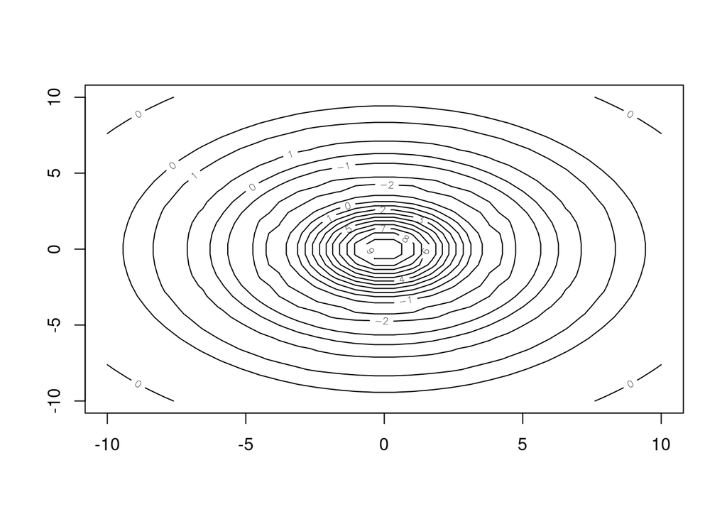

```r
contour(x,y,z)
```

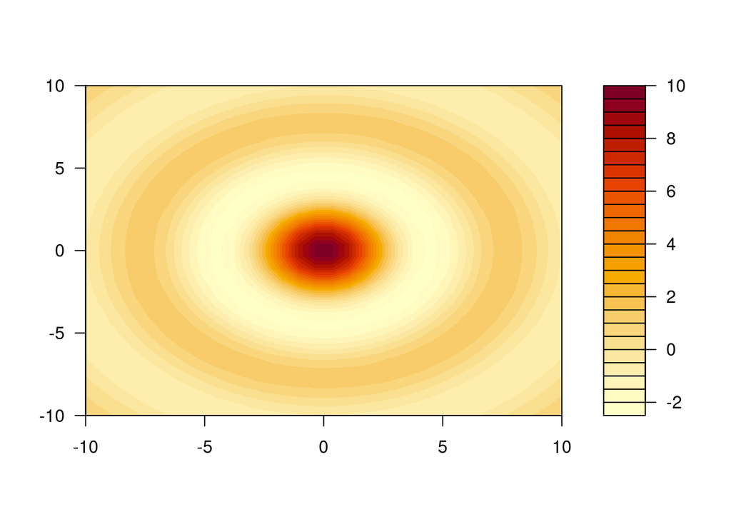

```r
filled.contour(x,y,z)
```

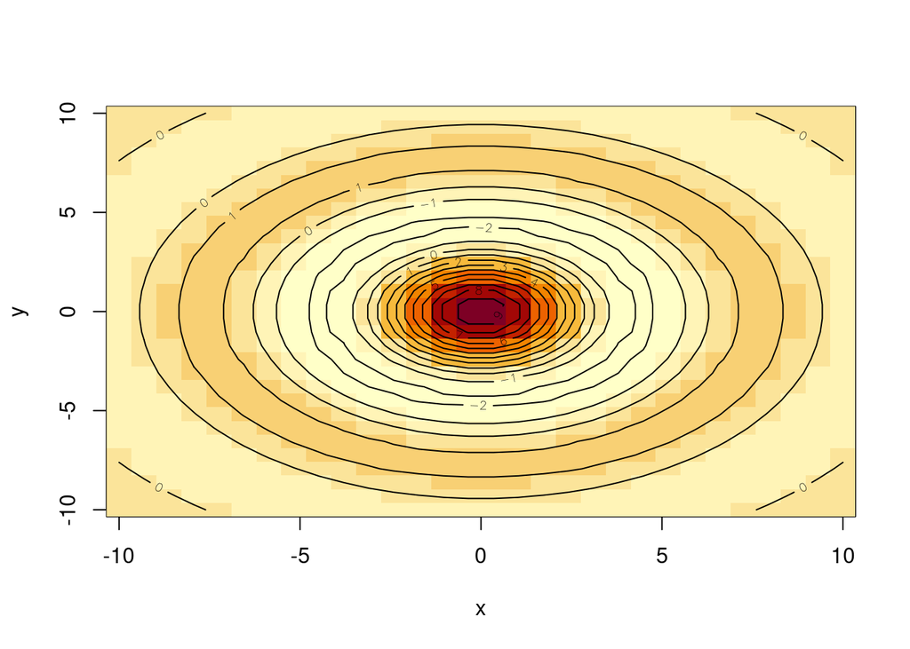

```r
image(x,y,z)
contour(x,y,z,add=T)
```

## Exercice

### Enoncé 1

1. Tracer la fonction arctangente entre $-10$ et $10$
2. Ajouter les deux asymptotes en $-\infty$ et $+\infty$ en bleu
3. Ajouter les points sur la courbe pour $x=-\pi$, $0$ et $\pi$ en vert
4. Ajouter la tangente en zéro en pointillés rouge

### Votre réponse

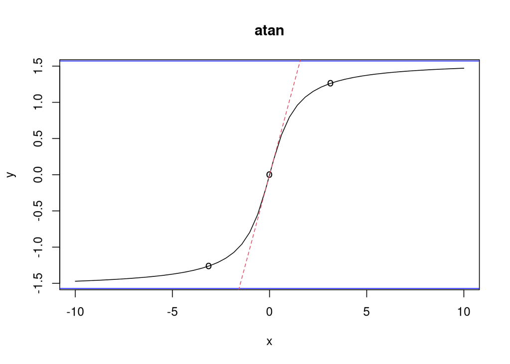

```r
#  A COMPLETER POUR REPONDRE A L'EXERCICE 1.
# AIDEZ VOUS DE LA CORRECTION DISPO SUR LE TUTORIEL SI VOUS ETES BLOQUE
x = seq(-10, 10, l = 50)
y = atan(x)
plot(x,y,type="l",xlab="x", ylab="y",main="atan")
abline(h = pi/2, col = "blue")
abline(h = -pi/2, col = "blue")
z=c(-pi,0,pi)
points(z, atan(z), pch = "o")
lines(c(-2, 2), c(-2, 2), lty = 2, col = 2)
```

## Exportation de graphiques

Lire les explications données dans le tutoriel.

# Programmation

Cette partie est consacrée à la création des fonctions, les instructions de contrôle, la syntaxe des itérations et la fonction **apply** (et ses dérivées).

## Créer une fonction

Il est possible sous R de construire ses propres fonctions. Il est conseillé d’écrire sa fonction dans un fichier `nomfonction.R`, puis dans la console, de charger la fonction grâce à la commande `>source("nomfonction.R")` et de l’utiliser. On peut également écrire directement la fonction dans la console. De manière générale, la définition d’une nouvelle fonction passe par l’expression suivante :

```r
nomfonction=function(arg1[=exp1],arg2[=exp2],...){
    bloc d instructions
    sortie = ...
    return(sortie)
}
```

Les accolades signalent le début et la fin du code source de la fonction, les crochets indiquent le caractère facultatif des valeurs par défaut des arguments. L’objet *sortie* contient le ou les résultats retournés par la fonction, on peut en particulier utiliser une liste pour retourner plusieurs résultats.

### Exemples

#### Exemple 1

```r
MaFonction=function(x){x+2}
MaFonction
```

```
function(x){x+2}
```

```r
MaFonction(3)
```

```
[1] 5
```

```r
x = MaFonction(4)
x
```

```
[1] 6
```

```r
Fonction2=function(a,b=7){a+b}
Fonction2(2,b=3)
```

```
[1] 5
```

```r
Fonction2(5)
```

```
[1] 12
```

#### Exemple 2

Fonction retournant le périmètre et la surface d’un cercle à partir de son rayon :

```r
CalculsCercle=function(r){
    p=2*pi*r
    s=pi*r*r
    resultats = list(perimetre=p,surface=s)
    return(resultats)
}
res=CalculsCercle(3)
res
```

```
$perimetre
[1] 18.84956

$surface
[1] 28.27433
```

```r
res$surf
```

```
[1] 28.27433
```

### Exercice :

#### Enoncé

1. Construire une fonction qui prend en argument deux réels x et y et qui retourne l’arrondi à 3 chiffres après la virgule de $x^2 + y$. (Vous pouvez vous aider de la fonction `round()`).
2. Construire une fonction qui permet de calculer la densité de probabilité d’une loi normale de moyenne $m$ et d’écart-type $s$ au point $x$.

#### Votre réponse

```r
f=function(x,y){
  return (round((x**2+y),3))
}
f(1,2.2359)
```

```
[1] 3.236
```

```r
densite = function(x, m, s) {
  return (exp(-((x - m)**2)/(2*s**2))/sqrt(2*pi*(s**2)))
}
densite(0,0,1)
```

```
[1] 0.3989423
```

```r
1/sqrt(2*pi)
```

```
[1] 0.3989423
```

```r
#  A COMPLETER POUR REPONDRE A L'EXERCICE
# AIDEZ VOUS DE LA CORRECTION DISPO SUR LE TUTORIEL SI VOUS ETES BLOQUE
```

## Structures de contrôle et itérations

### Instructions conditionnelles

La syntaxe `if(condition){instructions}` permet de calculer les instructions uniquement si la condition est vraie. Le code `if(condition){ A }else { B }` calcule les instructions A si la condition est vraie et les instructions B sinon. On peut également utiliser `ifelse`.

Dans l’exemple suivant, les deux commandes sont équivalentes :

```r
if(x>0){y=x*log(x)}else{ y=0}
y=ifelse(x>0,x*log(x),0)
```

#### Exercice

##### Enoncé

Soit $X$ une variable aléatoire de loi de Poisson de paramètre 2. Écrire une fonction qui prend en argument un réel $x$ et qui retourne la probabilité que $X$ soit égal à $x$.

##### Votre réponse

```r
p=function(x){
  if (x>0){
    return (exp(-2)*(2**x)/factorial(x))
  }
  else {
    return(0)
  }
}
p(-1)
```

```
[1] 0
```

```r
p(5)
```

```
[1] 0.03608941
```

```r
#  A COMPLETER POUR REPONDRE A L'EXERCICE
# AIDEZ VOUS DE LA CORRECTION DISPO SUR LE TUTORIEL SI VOUS ETES BLOQUE
```

### Itérations

On utilise les boucles pour exécuter plusieurs fois une instruction ou un bloc d’instructions. Les trois types de boucle sont :

- la boucle **for** : `for(var in seq){ commandes }`
- la boucle **while** : `while(cond){ commandes }`
- la boucle **repeat** : `repeat { commandes ; if (cond) break }`

Dans une boucle **for**, le nombre d’itérations est fixe alors qu’il peut être infini pour les boucles **while** et **repeat**!

#### Exemples

Pour illustrer les trois types de boucles, on a codé de trois façons différentes la somme des éléments d’un vecteur `x` ce qui correspond à la fonction `sum()` de R.

##### Exemple `for()`

```r
somme1=function(x){
t = 0
for (i in 1:length(x))
  t = t+x[i]
return(t)
}

x = seq(1:10)
somme1(x)
```

```
[1] 55
```

```r
sum(x)
```

```
[1] 55
```

##### Exemple `while()`

```r
somme2=function(x){
t = 0
i = 1
while (i<=length(x)){
t = t+x[i]
i = i+1
}
return(t)
}
x = seq(1:10)
somme2(x)
```

```
[1] 55
```

```r
sum(x)
```

```
[1] 55
```

##### Exemple `repeat()`

```r
somme3=function(x){
t = 0
i = 1
repeat{
t = t+x[i]
i = i+1
if (i> length(x)) break
}
return(t)
}

x = seq(1:10)
somme3(x)
```

```
[1] 55
```

```r
sum(x)
```

```
[1] 55
```

#### Exercice

##### Enoncé

1. Écrire une fonction *ma.variance* qui calcule la variance empirique corrigée pour un vecteur $x = (x_1, . . . , x_n)$. Comparer avec la fonction prédéfinie `var()`.
2. Écrire une fonction qui calcule les $n$ premiers termes de la suite de Fibonacci ($u_1=0, u_2=1, \forall n>2, u_n=u_{n-1}+u_{n-2}$)
3. Ecrire une fonction qui prend en entrée un entier $x$ et retourne sa factorielle $x!$ avec une boucle *for()* puis avec une boucle *while()*.

##### Votre réponse

```r
ma.variance=function(x){
  s=0
  xb=mean(x)
  for (i in 1:length(x)) s= s+(x[i]-xb)**2
  return(s/(length(x)-1))
}
x= 1:15
ma.variance(x)
```

```
[1] 20
```

```r
var(x)
```

```
[1] 20
```

```r
fi=function(n){
  if (n==1) return(0)
  else if (n==2) return (1)
  else{
    un1=1
    un2=0
    for (i in 3:n){
      aux=un1
      un1=un1+un2
      un2=aux
    }
    return(un1)
  }
}
fi(1)
```

```
[1] 0
```

```r
fi(2)
```

```
[1] 1
```

```r
fi(3)
```

```
[1] 1
```

```r
fi(10)
```

```
[1] 34
```

```r
fac=function(x){
  p=1
  for (i in 1:x) p=p*i
  return(p)
}
fac(3)
```

```
[1] 6
```

```r
fac(5)
```

```
[1] 120
```

```r
fac2=function(x){
  p=1
  i=1
  while (i <=x) {
    p=p*i
    i=i+1
  }
  return(p)
}
fac2(3)
```

```
[1] 6
```

```r
fac2(5)
```

```
[1] 120
```

```r
#  A COMPLETER POUR REPONDRE A L'EXERCICE
# AIDEZ VOUS DE LA CORRECTION DISPO SUR LE TUTORIEL SI VOUS ETES BLOQUE
```

## `apply()` et ses variantes

Il est recommandé d’éviter les boucles très chronophages. On peut utiliser pour cela la fonction `apply()` et ses variantes `sapply()`, `lapply()`, `tapply()` sur des vecteurs ou matrices.

La fonction `apply()` permet d’appliquer la même fonction *FUN* sur toutes les lignes *(MARGIN=1)* ou les colonnes *(MARGIN=2)* d’une matrice *MAT* : `apply(MAT , MARGIN, FUN)`.

Les fonctions `lapply()` et `sapply()` calculent la même fonction sur tous les éléments d’un vecteur ou d’une liste. La commande `lapply(X,FUN, ARG.COMMUN)` permet d’appliquer la fonction *FUN* à tous les éléments du vecteur ou de la liste *X*. Les valeurs de *X* sont affectées au premier argument de la fonction *FUN*. Si la fonction *FUN* a plusieurs paramètres d’entrée, ils sont spécifiés dans *ARG.COMMUN*. Cette fonction retourne le résultat sous la forme de listes. `sapply()` est une fonction similaire à `lapply()` mais le résultat est retourné sous forme de vecteurs, si possible.

La fonction `tapply()` applique une fonction *FUN* sur les sous-groupes d’un vecteur *X* définis par une variable de type factor *GRP* : `tapply(X,GRP,FUN,...)`.

### Exemples

```r
data(iris)
head(iris)
```

```
  Sepal.Length Sepal.Width Petal.Length Petal.Width Species
1          5.1         3.5          1.4         0.2  setosa
2          4.9         3.0          1.4         0.2  setosa
3          4.7         3.2          1.3         0.2  setosa
4          4.6         3.1          1.5         0.2  setosa
5          5.0         3.6          1.4         0.2  setosa
6          5.4         3.9          1.7         0.4  setosa
```

```r
apply(iris[,1:4],2,sum)
```

```
Sepal.Length  Sepal.Width Petal.Length  Petal.Width
       876.5        458.6        563.7        179.9
```

```r
apply(iris[,1:4],1,sum)
```

```
  [1] 10.2  9.5  9.4  9.4 10.2 11.4  9.7 10.1  8.9  9.6 10.8 10.0  9.3  8.5 11.2
 [16] 12.0 11.0 10.3 11.5 10.7 10.7 10.7  9.4 10.6 10.3  9.8 10.4 10.4 10.2  9.7
 [31]  9.7 10.7 10.9 11.3  9.7  9.6 10.5 10.0  8.9 10.2 10.1  8.4  9.1 10.7 11.2
 [46]  9.5 10.7  9.4 10.7  9.9 16.3 15.6 16.4 13.1 15.4 14.3 15.9 11.6 15.4 13.2
 [61] 11.5 14.6 13.2 15.1 13.4 15.6 14.6 13.6 14.4 13.1 15.7 14.2 15.2 14.8 14.9
 [76] 15.4 15.8 16.4 14.9 12.8 12.8 12.6 13.6 15.4 14.4 15.5 16.0 14.3 14.0 13.3
 [91] 13.7 15.1 13.6 11.6 13.8 14.1 14.1 14.7 11.7 13.9 18.1 15.5 18.1 16.6 17.5
[106] 19.3 13.6 18.3 16.8 19.4 16.8 16.3 17.4 15.2 16.1 17.2 16.8 20.4 19.5 14.7
[121] 18.1 15.3 19.2 15.7 17.8 18.2 15.6 15.8 16.9 17.6 18.2 20.1 17.0 15.7 15.7
[136] 19.1 17.7 16.8 15.6 17.5 17.8 17.4 15.5 18.2 18.2 17.2 15.7 16.7 17.3 15.8
```

```r
lapply(iris[,1:4],sum)
```

```
$Sepal.Length
[1] 876.5

$Sepal.Width
[1] 458.6

$Petal.Length
[1] 563.7

$Petal.Width
[1] 179.9
```

```r
sapply(iris[,1:4],sum)
```

```
Sepal.Length  Sepal.Width Petal.Length  Petal.Width
       876.5        458.6        563.7        179.9
```

```r
tapply(iris[,1],iris[,5],sum)
```

```
    setosa versicolor  virginica
     250.3      296.8      329.4
```

### Exercices

#### Enoncé 1

Soit la fonction suivante :

```r
Exo1=function(M){
  res=rep(0,5)
  for (i in 1:5){
    tmp=0
    for (j in 1:4) {tmp = tmp + M[i,j]}
    res[i]=tmp
  }
return(res)
}

M=matrix(1:20,nrow=5,ncol=4)
Exo1(M)
```

Proposer une fonction équivalente sans aucune boucle.

#### Enoncé 2

1. Réaliser une liste de $100$ réalisations d’une loi normale $\mathcal{N}(m,1)$ pour $m=-2$, $0$ et $2$ respectivement en utilisant `lapply()` et `rnorm()`.
2. Créer un vecteur contenant la moyenne de chaque échantillon de la question 1.

#### Votre réponse

```r
E1=function(M){
  return(apply(M,2,sum))
}
E1(M)
```

```
 [1]  55 155 255 355 455 555 655 755 855 955
```

```r
#  A COMPLETER POUR REPONDRE A L'EXERCICE
# AIDEZ VOUS DE LA CORRECTION DISPO SUR LE TUTORIEL SI VOUS ETES BLOQUE
```

# Entrée / Sortie

## Importation d’un jeu de données

Lire les explications données dans le tutoriel.

### Exercice

#### Enoncé

Executez les commandes suivantes pour préparer l’exercice.

```r
data(iris)
dir.create("DataAux")
write.table(iris,file="DataAux/iris1.txt",sep=";",row.names=F,col.names=T)
rownames(iris)=paste("indiv",1:nrow(iris),sep="-")
write.table(iris,file="DataAux/iris2.csv",row.names=T,col.names=F)
write.table(iris,file="DataAux/iris3.txt",quote=FALSE, dec=",",sep="*")
```

Chargez à l’aide de la fonction `read.table()` les données *iris1.txt*, *iris2.csv* et *iris3.txt* disponibles dans le dossier *DataAux*.

#### Votre réponse

```r
#  A COMPLETER POUR REPONDRE A L'EXERCICE
# AIDEZ VOUS DE LA CORRECTION DISPO SUR LE TUTORIEL SI VOUS ETES BLOQUE
```

## Exportation

Lire les explications données dans le tutoriel.